# Assignment-4

```python
#Azat Dovgeldiyev
#import dependencies
import numpy as np
import pandas as pd
```

### 1. PCA for Reduced Dimensionality in Clustering

#### a)

Load in the image data matrix (with rows as images and columns as features). Also load in the numeric class labels from the segmentation class file. Using your favorite method (e.g., sklearn's min-max scaler), perform min-max normalization on the data matrix so that each feature is scaled to [0,1] range.

```python
df = pd.read_csv("segmentation_data/segmentation_data.txt", header=None)
df.head()
```

|  | 0 | 1 | 2 | 3 | 4 | 5 | 6 | 7 | 8 | 9 | 10 | 11 | 12 | 13 | 14 | 15 | 16 | 17 | 18 |
| --- | --- | --- | --- | --- | --- | --- | --- | --- | --- | --- | --- | --- | --- | --- | --- | --- | --- | --- | --- |
| 0 | 110.0 | 189.0 | 9 | 0.0 | 0.0 | 1.000000 | 0.666667 | 1.222222 | 1.186342 | 12.925926 | 10.888889 | 9.222222 | 18.666668 | -6.111111 | -11.111111 | 17.222221 | 18.666668 | 0.508139 | 1.910864 |
| 1 | 86.0 | 187.0 | 9 | 0.0 | 0.0 | 1.111111 | 0.720082 | 1.444444 | 0.750309 | 13.740741 | 11.666667 | 10.333334 | 19.222221 | -6.222222 | -10.222222 | 16.444445 | 19.222221 | 0.463329 | 1.941465 |
| 2 | 225.0 | 244.0 | 9 | 0.0 | 0.0 | 3.388889 | 2.195113 | 3.000000 | 1.520234 | 12.259259 | 10.333334 | 9.333334 | 17.111110 | -5.777778 | -8.777778 | 14.555555 | 17.111110 | 0.480149 | 1.987902 |
| 3 | 47.0 | 232.0 | 9 | 0.0 | 0.0 | 1.277778 | 1.254621 | 1.000000 | 0.894427 | 12.703704 | 11.000000 | 9.000000 | 18.111110 | -5.111111 | -11.111111 | 16.222221 | 18.111110 | 0.500966 | 1.875362 |
| 4 | 97.0 | 186.0 | 9 | 0.0 | 0.0 | 1.166667 | 0.691215 | 1.166667 | 1.005540 | 15.592592 | 13.888889 | 11.777778 | 21.111110 | -5.111111 | -11.444445 | 16.555555 | 21.111110 | 0.442661 | 1.863654 |

```python
classes = pd.read_csv("segmentation_data/segmentation_classes.txt", header = None, sep='\t')
classes = classes.iloc[:,1]
classes.head()
```

```
0    0
1    0
2    0
3    0
4    0
Name: 1, dtype: int64
```

```python
from sklearn.preprocessing import MinMaxScaler

min_max_scaler = MinMaxScaler()
X_norm = min_max_scaler.fit_transform(df)
X_norm
```

```
array([[0.43083004, 0.74166667, 0.        , ..., 0.12371135, 0.50813884,
        0.83184923],
       [0.33596838, 0.73333333, 0.        , ..., 0.12739322, 0.46332908,
        0.83698646],
       [0.88537549, 0.97083333, 0.        , ..., 0.11340205, 0.48014903,
        0.84478233],
       ...,
       [0.50197628, 0.625     , 0.        , ..., 0.07216495, 0.5409177 ,
        0.17591546],
       [0.58893281, 0.6125    , 0.        , ..., 0.08100147, 0.50308645,
        0.18478933],
       [0.48616601, 0.62916667, 0.        , ..., 0.09646539, 0.4799313 ,
        0.17037463]])
```

#### b)

Using the Kmeans implementation in scikit-learn, perform clustering on the image data (use K = 7 in your clustering so that later we can compare the clusters to the 7 pre-assigned image classes). Print the cluster centroids (use some formatting so that they are visually understandable). To evaluate your clusters, first perform Silhouette analysis on the clusters (compute Silhouette values for all instances in the data, and then compute the overall mean Silhouette value; optionally, you can provide a visaulization of the Silhouettes). Next, compare your 7 clusters to the 7 pre-assigned classes by computing the Completeness and Homogeneity values of the generated clusters.

```python
from sklearn.cluster import KMeans

kmeans = KMeans(n_clusters=7, max_iter=1000, verbose=0)
kmeans.fit(X_norm)
```

```
KMeans(algorithm='auto', copy_x=True, init='k-means++', max_iter=1000,
       n_clusters=7, n_init=10, n_jobs=None, precompute_distances='auto',
       random_state=None, tol=0.0001, verbose=0)
```

```python
clusters = kmeans.predict(X_norm)
clusters[:500]
```

```
array([3, 3, 3, 3, 3, 3, 3, 3, 3, 3, 3, 3, 3, 3, 3, 3, 3, 3, 3, 3, 3, 3,
       3, 3, 3, 3, 3, 3, 3, 3, 3, 3, 3, 3, 3, 3, 3, 3, 3, 3, 3, 3, 3, 3,
       3, 3, 3, 3, 5, 2, 5, 5, 5, 5, 2, 2, 5, 5, 5, 5, 5, 5, 5, 2, 5, 5,
       5, 5, 2, 5, 2, 5, 2, 5, 5, 5, 5, 5, 2, 5, 5, 5, 5, 5, 5, 5, 5, 5,
       5, 2, 5, 2, 5, 5, 5, 5, 5, 5, 5, 5, 5, 5, 2, 5, 5, 5, 5, 5, 2, 5,
       5, 5, 5, 5, 5, 5, 5, 5, 5, 2, 5, 5, 5, 5, 2, 5, 2, 5, 5, 5, 2, 2,
       2, 5, 2, 5, 5, 0, 0, 0, 0, 0, 0, 0, 0, 0, 0, 0, 0, 0, 0, 0, 0, 0,
       0, 0, 0, 0, 0, 0, 0, 0, 0, 0, 0, 0, 6, 0, 0, 0, 0, 0, 0, 0, 0, 0,
       0, 0, 0, 0, 0, 0, 0, 0, 0, 0, 0, 0, 0, 0, 0, 0, 0, 0, 0, 0, 0, 0,
       0, 0, 0, 0, 0, 0, 0, 0, 0, 0, 0, 0, 0, 0, 0, 0, 0, 0, 0, 0, 0, 0,
       0, 0, 0, 0, 0, 0, 0, 0, 0, 0, 0, 0, 0, 2, 5, 5, 2, 5, 2, 2, 5, 0,
       5, 2, 5, 2, 5, 2, 2, 2, 4, 2, 2, 5, 5, 2, 2, 2, 2, 5, 2, 5, 5, 2,
       5, 5, 5, 2, 2, 2, 5, 4, 5, 2, 2, 2, 2, 2, 5, 5, 5, 5, 5, 4, 2, 2,
       2, 4, 2, 5, 2, 5, 5, 2, 2, 2, 5, 2, 4, 5, 2, 2, 2, 2, 2, 2, 2, 2,
       2, 5, 5, 5, 2, 5, 5, 2, 5, 4, 2, 2, 5, 2, 2, 2, 5, 2, 4, 5, 2, 2,
       2, 2, 5, 2, 4, 2, 2, 2, 2, 2, 5, 2, 4, 2, 5, 5, 2, 5, 2, 2, 5, 5,
       5, 2, 2, 5, 2, 4, 2, 2, 2, 2, 2, 2, 2, 2, 5, 2, 5, 2, 4, 5, 2, 5,
       2, 2, 2, 5, 4, 5, 2, 4, 5, 5, 5, 5, 5, 2, 2, 2, 5, 2, 5, 2, 6, 4,
       6, 4, 4, 6, 4, 0, 4, 6, 4, 4, 4, 6, 6, 6, 6, 4, 4, 6, 6, 4, 4, 6,
       4, 4, 4, 4, 4, 6, 6, 4, 6, 4, 4, 6, 4, 6, 6, 6, 6, 4, 6, 4, 6, 2,
       6, 6, 2, 6, 4, 4, 6, 6, 4, 2, 4, 6, 6, 6, 6, 6, 4, 6, 6, 6, 4, 6,
       4, 6, 0, 4, 4, 6, 6, 4, 6, 4, 6, 4, 4, 6, 6, 6, 6, 6, 6, 6, 4, 4,
       4, 4, 4, 6, 6, 6, 6, 4, 4, 6, 1, 1, 1, 1, 1, 1])
```

```python
#Print the cluster centroids (use some formatting so that they are visually understandable)
names = pd.read_csv("segmentation_data/segmentation_names.txt", header = None, sep='\t')
pd.options.display.float_format = '{:,.2f}'.format
centroids = pd.DataFrame(kmeans.cluster_centers_, columns = names)
centroids
```

|  | (REGION-CENTROID-COL,) | (REGION-CENTROID-ROW,) | (REGION-PIXEL-COUNT,) | (SHORT-LINE-DENSITY-5,) | (SHORT-LINE-DENSITY-2,) | (VEDGE-MEAN,) | (VEDGE-SD,) | (HEDGE-MEAN,) | (HEDGE-SD,) | (INTENSITY-MEAN,) | (RAWRED-MEAN,) | (RAWBLUE-MEAN,) | (RAWGREEN-MEAN,) | (EXRED-MEAN,) | (EXBLUE-MEAN,) | (EXGREEN-MEAN,) | (VALUE-MEAN,) | (SATURATION-MEAN,) | (HUE-MEAN,) |
| --- | --- | --- | --- | --- | --- | --- | --- | --- | --- | --- | --- | --- | --- | --- | --- | --- | --- | --- | --- |
| 0 | 0.77 | 0.43 | 0.00 | 0.01 | 0.02 | 0.04 | 0.00 | 0.02 | 0.00 | 0.04 | 0.04 | 0.06 | 0.03 | 0.78 | 0.22 | 0.49 | 0.06 | 0.54 | 0.24 |
| 1 | 0.54 | 0.15 | 0.00 | 0.03 | 0.00 | 0.03 | 0.00 | 0.03 | 0.00 | 0.82 | 0.78 | 0.89 | 0.79 | 0.27 | 0.67 | 0.29 | 0.89 | 0.21 | 0.13 |
| 2 | 0.30 | 0.53 | 0.00 | 0.05 | 0.05 | 0.10 | 0.01 | 0.08 | 0.01 | 0.40 | 0.37 | 0.47 | 0.35 | 0.50 | 0.57 | 0.21 | 0.47 | 0.30 | 0.16 |
| 3 | 0.51 | 0.81 | 0.00 | 0.08 | 0.01 | 0.05 | 0.00 | 0.05 | 0.00 | 0.11 | 0.09 | 0.09 | 0.14 | 0.68 | 0.08 | 0.82 | 0.13 | 0.41 | 0.89 |
| 4 | 0.26 | 0.39 | 0.00 | 0.07 | 0.02 | 0.08 | 0.00 | 0.06 | 0.00 | 0.15 | 0.14 | 0.19 | 0.12 | 0.72 | 0.34 | 0.36 | 0.19 | 0.41 | 0.20 |
| 5 | 0.75 | 0.53 | 0.00 | 0.04 | 0.04 | 0.11 | 0.02 | 0.11 | 0.02 | 0.30 | 0.28 | 0.35 | 0.27 | 0.59 | 0.45 | 0.31 | 0.35 | 0.30 | 0.16 |
| 6 | 0.25 | 0.46 | 0.00 | 0.03 | 0.01 | 0.04 | 0.00 | 0.03 | 0.00 | 0.03 | 0.02 | 0.04 | 0.02 | 0.77 | 0.22 | 0.51 | 0.04 | 0.80 | 0.18 |

```python
#compute Silhouette values for all instances in the data, and then compute the overall mean Silhouette value;
from sklearn import metrics

silhouettes = metrics.silhouette_samples(X_norm,clusters)
print(silhouettes[:20])
```

```
[0.57236961 0.5609926  0.46573747 0.49551578 0.57187855 0.56013527
 0.54247867 0.41254281 0.51997981 0.46760414 0.48688779 0.49140278
 0.58437635 0.56254708 0.3794524  0.5311416  0.54891047 0.4226305
 0.4161636  0.40382238]
```

```python
print(silhouettes.mean())
```

```
0.3320776409159453
```

```python
#copied from class example (Clustering)
import pylab as pl

def plot_silhouettes(data, clusters, metric='euclidean'):

    from matplotlib import cm
    from sklearn.metrics import silhouette_samples

    cluster_labels = np.unique(clusters)
    n_clusters = cluster_labels.shape[0]
    silhouette_vals = metrics.silhouette_samples(data, clusters, metric='euclidean')
    c_ax_lower, c_ax_upper = 0, 0
    cticks = []
    for i, k in enumerate(cluster_labels):
        c_silhouette_vals = silhouette_vals[clusters == k]
        c_silhouette_vals.sort()
        c_ax_upper += len(c_silhouette_vals)
        color = cm.jet(float(i) / n_clusters)
        pl.barh(range(c_ax_lower, c_ax_upper), c_silhouette_vals, height=1.0,
                      edgecolor='none', color=color)

        cticks.append((c_ax_lower + c_ax_upper) / 2)
        c_ax_lower += len(c_silhouette_vals)

    silhouette_avg = np.mean(silhouette_vals)
    pl.axvline(silhouette_avg, color="red", linestyle="--")

    pl.yticks(cticks, cluster_labels)
    pl.ylabel('Cluster')
    pl.xlabel('Silhouette coefficient')

    pl.tight_layout()
    #pl.savefig('images/11_04.png', dpi=300)
    pl.show()

    return
```

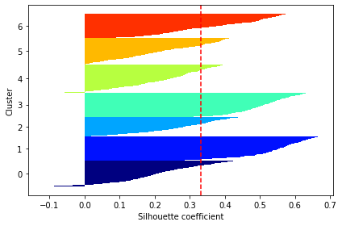

```python
plot_silhouettes(X_norm, clusters)
```

```python
'''
Next, compare your 7 clusters to the 7 pre-assigned classes by computing
the Completeness and Homogeneity values of the generated clusters.
'''
from sklearn.metrics import completeness_score, homogeneity_score

print('The Completeness score: ',completeness_score(classes, clusters))
print('The Homogeneity score: ',homogeneity_score(classes, clusters))
```

```
The Completeness score:  0.6132074717141492
The Homogeneity score:  0.6115130439578844
```

#### c)

Perform PCA on the normalized image data matrix. You may use the linear algebra package in Numpy or the Decomposition module in scikit-learn (the latter is much more efficient). Analyze the principal components to determine the number, r, of PCs needed to capture at least 95% of variance in the data. Provide a plot of PC variances. Then use these r components as features to transform the data into a reduced dimension space.

```python
from sklearn import decomposition

meanVals = np.mean(X_norm, axis = 0)
meanRemoved = X_norm - meanVals # remove mean
covMat = np.cov(meanRemoved, rowvar=0)

np.set_printoptions(precision=2, suppress = True, linewidth=100)
print(covMat)
```

```
[[ 0.08  0.    0.   -0.   -0.   -0.    0.   -0.    0.    0.    0.    0.01  0.01 -0.01  0.    0.
   0.01 -0.01  0.  ]
 [ 0.    0.06  0.    0.    0.    0.   -0.    0.   -0.   -0.03 -0.03 -0.03 -0.03  0.02 -0.02  0.02
  -0.03  0.    0.04]
 [ 0.    0.    0.    0.    0.    0.    0.    0.    0.    0.    0.    0.    0.    0.    0.    0.
   0.    0.    0.  ]
 [-0.    0.    0.    0.02 -0.   -0.   -0.   -0.   -0.   -0.   -0.   -0.   -0.    0.   -0.    0.
  -0.   -0.    0.  ]
 [-0.    0.    0.   -0.    0.01  0.    0.    0.    0.   -0.   -0.   -0.   -0.   -0.    0.   -0.
  -0.    0.   -0.  ]
 [-0.    0.    0.   -0.    0.    0.01  0.    0.    0.   -0.   -0.    0.   -0.   -0.    0.   -0.
   0.   -0.   -0.  ]
 [ 0.   -0.    0.   -0.    0.    0.    0.    0.    0.   -0.   -0.    0.    0.   -0.    0.    0.
   0.    0.   -0.  ]
 [-0.    0.    0.   -0.    0.    0.    0.    0.01  0.    0.    0.    0.    0.   -0.    0.   -0.
   0.   -0.   -0.  ]
 [ 0.   -0.    0.   -0.    0.    0.    0.    0.    0.    0.    0.    0.    0.   -0.    0.   -0.
   0.   -0.   -0.  ]
 [ 0.   -0.03  0.   -0.   -0.   -0.   -0.    0.    0.    0.07  0.07  0.08  0.07 -0.04  0.04 -0.03
   0.08 -0.04 -0.02]
 [ 0.   -0.03  0.   -0.   -0.   -0.   -0.    0.    0.    0.07  0.07  0.07  0.06 -0.04  0.04 -0.03
   0.07 -0.04 -0.02]
 [ 0.01 -0.03  0.   -0.   -0.    0.    0.    0.    0.    0.08  0.07  0.08  0.07 -0.05  0.05 -0.03
   0.08 -0.04 -0.03]
 [ 0.01 -0.03  0.   -0.   -0.   -0.    0.    0.    0.    0.07  0.06  0.07  0.06 -0.04  0.04 -0.02
   0.07 -0.04 -0.02]
 [-0.01  0.02  0.    0.   -0.   -0.   -0.   -0.   -0.   -0.04 -0.04 -0.05 -0.04  0.04 -0.03  0.02
  -0.05  0.02  0.01]
 [ 0.   -0.02  0.   -0.    0.    0.    0.    0.    0.    0.04  0.04  0.05  0.04 -0.03  0.04 -0.03
   0.05 -0.02 -0.03]
 [ 0.    0.02  0.    0.   -0.   -0.    0.   -0.   -0.   -0.03 -0.03 -0.03 -0.02  0.02 -0.03  0.04
  -0.03  0.01  0.04]
 [ 0.01 -0.03  0.   -0.   -0.    0.    0.    0.    0.    0.08  0.07  0.08  0.07 -0.05  0.05 -0.03
   0.08 -0.04 -0.03]
 [-0.01  0.    0.   -0.    0.   -0.    0.   -0.   -0.   -0.04 -0.04 -0.04 -0.04  0.02 -0.02  0.01
  -0.04  0.05 -0.  ]
 [ 0.    0.04  0.    0.   -0.   -0.   -0.   -0.   -0.   -0.02 -0.02 -0.03 -0.02  0.01 -0.03  0.04
  -0.03 -0.    0.07]]
```

```python
import numpy.linalg as la
eigVals, eigVects = la.eig(np.mat(covMat))
```

```python
print(eigVals)
```

```
[0.48 0.1  0.08 0.04 0.03 0.02 0.01 0.01 0.01 0.01 0.   0.   0.   0.   0.   0.   0.   0.   0.  ]
```

```python
print(eigVects)
```

```
[[ 0.03 -0.35  0.93  0.04  0.01 -0.03  0.01  0.03 -0.   -0.02 -0.01 -0.01  0.    0.    0.    0.
  -0.    0.    0.  ]
 [-0.19 -0.38 -0.12 -0.66  0.47 -0.14 -0.24  0.22  0.06  0.07  0.06  0.04  0.01 -0.01 -0.    0.
  -0.    0.    0.  ]
 [ 0.    0.    0.    0.    0.    0.    0.    0.    0.    0.    0.    0.    0.    0.    0.    0.
   0.    0.    1.  ]
 [-0.01 -0.03 -0.04 -0.03 -0.06 -0.6   0.72  0.32  0.06  0.08  0.01  0.01  0.   -0.   -0.    0.
   0.   -0.    0.  ]
 [-0.    0.02  0.01 -0.1   0.09  0.44  0.28  0.32 -0.77  0.05  0.07  0.   -0.01  0.    0.   -0.
  -0.   -0.    0.  ]
 [ 0.    0.02  0.01 -0.12  0.03  0.42  0.3   0.11  0.44 -0.34  0.55 -0.28  0.11 -0.01  0.    0.
  -0.    0.    0.  ]
 [ 0.    0.01  0.01 -0.01  0.01  0.18  0.12  0.07  0.18 -0.14  0.05  0.77 -0.55  0.01 -0.   -0.
  -0.   -0.    0.  ]
 [ 0.01  0.   -0.   -0.14  0.03  0.33  0.19  0.16  0.29 -0.02 -0.77 -0.29 -0.21 -0.01  0.   -0.
   0.    0.    0.  ]
 [ 0.    0.    0.   -0.02  0.01  0.16  0.09  0.07  0.13 -0.05 -0.24  0.49  0.8   0.01  0.    0.
   0.   -0.    0.  ]
 [ 0.38 -0.11 -0.06  0.09  0.05 -0.02 -0.08  0.16  0.01 -0.05  0.   -0.    0.   -0.21 -0.04  0.06
   0.64 -0.63  0.  ]
 [ 0.36 -0.11 -0.07  0.09 -0.01 -0.04 -0.13  0.24  0.   -0.11 -0.   -0.01  0.   -0.21 -0.52  0.55
  -0.5   0.02  0.  ]
 [ 0.41 -0.07 -0.04  0.03  0.08 -0.03 -0.04  0.07 -0.01 -0.06 -0.01  0.    0.   -0.22  0.81  0.1
  -0.33  0.17  0.  ]
 [ 0.36 -0.16 -0.08  0.14  0.06  0.01 -0.08  0.18  0.04  0.02  0.02 -0.    0.   -0.21 -0.19 -0.73
   0.18  0.45  0.  ]
 [-0.24  0.06  0.    0.01 -0.39 -0.13 -0.31  0.5  -0.05 -0.42 -0.04 -0.03  0.    0.08  0.11 -0.25
  -0.17 -0.26  0.  ]
 [ 0.26  0.18  0.08 -0.27  0.18 -0.04  0.18 -0.4  -0.08 -0.08 -0.04  0.02 -0.   -0.08 -0.11 -0.3
  -0.32 -0.45  0.  ]
 [-0.18 -0.34 -0.13  0.43  0.11  0.2   0.03  0.14  0.17  0.55  0.1  -0.   -0.    0.05  0.06 -0.07
  -0.26 -0.32  0.  ]
 [ 0.41 -0.1  -0.06  0.04  0.1  -0.02 -0.03  0.06 -0.   -0.07 -0.01 -0.02 -0.    0.89  0.   -0.
  -0.    0.    0.  ]
 [-0.2   0.31  0.08  0.42  0.74 -0.12 -0.03  0.13 -0.01 -0.3  -0.06 -0.03 -0.   -0.01 -0.    0.
  -0.   -0.    0.  ]
 [-0.17 -0.64 -0.24  0.2  -0.01 -0.02  0.18 -0.35 -0.18 -0.5  -0.12 -0.02 -0.   -0.04 -0.    0.
  -0.    0.    0.  ]]
```

```python
eigValInd = np.argsort(eigVals) # sort, sort goes smallest to largest
eigValInd = eigValInd[::-1] #reverse
sortedEigVals = eigVals[eigValInd]
print(sortedEigVals)
total = sum(sortedEigVals)
varPercentage = sortedEigVals / total*100
print(varPercentage)
```

```
[0.48 0.1  0.08 0.04 0.03 0.02 0.01 0.01 0.01 0.01 0.   0.   0.   0.   0.   0.   0.   0.   0.  ]
[60.71 13.2  10.12  4.54  3.55  1.99  1.89  1.62  1.07  0.71  0.39  0.16  0.05  0.    0.    0.
  0.    0.    0.  ]
```

```python
var = 0
for i in range(10):
    var += varPercentage[i]/100
    print("{} PC: {}".format(i+1, round(var,4)))
    if var >= 0.95:
        break
```

```
1 PC: 0.6071
2 PC: 0.7391
3 PC: 0.8403
4 PC: 0.8858
5 PC: 0.9213
6 PC: 0.9411
7 PC: 0.9601
```

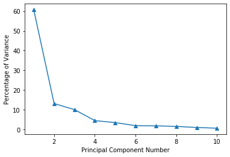

```python
import matplotlib.pyplot as plt
%matplotlib inline

fig = plt.figure()
ax = fig.add_subplot(111)
ax.plot(range(1, 11), varPercentage[:10], marker='^')
plt.xlabel('Principal Component Number')
plt.ylabel('Percentage of Variance')
plt.show()
```

```python
'''
Analyze the principal components to determine the number,
r, of PCs needed to capture at least 95% of variance in the data.
'''
topNfeat = 7
topEigValInd = eigValInd[:topNfeat]
reducedEigVects = eigVects[:, topEigValInd]
reducedDT = np.dot(meanRemoved, reducedEigVects)
print(reducedDT)
```

```
[[-0.69 -0.53 -0.25 ...  0.08  0.05 -0.05]
 [-0.67 -0.51 -0.34 ...  0.04  0.06 -0.04]
 [-0.71 -0.77  0.16 ...  0.17  0.04 -0.06]
 ...
 [-0.51  0.13  0.08 ...  0.03 -0.03 -0.11]
 [-0.48  0.09  0.16 ... -0.   -0.   -0.09]
 [-0.44  0.11  0.05 ... -0.02 -0.21  0.15]]
```

#### d)

Perform Kmeans again, but this time on the lower dimensional transformed data. Then compare Silhouette values as well as completeness and Homogeneity values of the new clusters. Compare these results with those obtained on the full data in part b.

```python
kmeans = KMeans(n_clusters=7, max_iter=1000, verbose=0)
kmeans.fit(reducedDT)
```

```
KMeans(algorithm='auto', copy_x=True, init='k-means++', max_iter=1000,
       n_clusters=7, n_init=10, n_jobs=None, precompute_distances='auto',
       random_state=None, tol=0.0001, verbose=0)
```

```python
clusters = kmeans.predict(reducedDT)
clusters[:500]
```

```
array([3, 3, 3, 3, 3, 3, 3, 3, 3, 3, 3, 3, 3, 3, 3, 3, 3, 3, 3, 3, 3, 3, 3, 3, 3, 3, 3, 3, 3, 3, 3,
       3, 3, 3, 3, 3, 3, 3, 3, 3, 3, 3, 3, 3, 3, 3, 3, 3, 2, 6, 2, 2, 2, 2, 6, 6, 2, 2, 2, 2, 2, 2,
       2, 6, 2, 2, 2, 2, 6, 2, 6, 2, 6, 2, 2, 2, 2, 2, 6, 2, 2, 2, 2, 2, 2, 2, 2, 2, 2, 6, 2, 6, 2,
       2, 2, 2, 2, 2, 2, 2, 2, 2, 6, 2, 2, 2, 2, 2, 6, 2, 2, 2, 2, 2, 2, 2, 6, 2, 2, 6, 2, 2, 2, 2,
       6, 2, 6, 2, 2, 2, 6, 6, 6, 2, 6, 2, 2, 4, 4, 4, 4, 4, 4, 4, 4, 4, 4, 4, 4, 4, 4, 4, 4, 4, 4,
       4, 4, 4, 4, 4, 4, 4, 4, 4, 4, 4, 4, 4, 4, 4, 4, 4, 4, 4, 4, 4, 4, 4, 4, 4, 4, 4, 4, 4, 4, 4,
       4, 4, 4, 4, 4, 4, 4, 4, 4, 4, 4, 4, 4, 4, 4, 4, 4, 4, 4, 4, 4, 4, 4, 4, 4, 4, 4, 4, 4, 4, 4,
       4, 4, 4, 4, 4, 4, 4, 4, 4, 4, 4, 4, 4, 4, 4, 4, 6, 2, 2, 6, 2, 6, 6, 2, 4, 2, 6, 2, 6, 2, 6,
       6, 6, 5, 6, 6, 2, 2, 6, 6, 6, 6, 2, 6, 2, 2, 6, 2, 2, 2, 6, 6, 6, 2, 5, 2, 6, 6, 6, 6, 6, 2,
       2, 2, 2, 2, 5, 6, 6, 6, 5, 6, 2, 6, 2, 2, 6, 6, 6, 2, 6, 5, 2, 6, 6, 6, 6, 6, 6, 6, 6, 6, 2,
       2, 2, 6, 2, 2, 6, 2, 5, 6, 6, 2, 6, 6, 6, 2, 6, 5, 2, 6, 6, 6, 6, 2, 6, 5, 6, 6, 6, 6, 6, 2,
       6, 5, 6, 2, 2, 6, 2, 6, 6, 2, 2, 2, 6, 6, 2, 6, 5, 6, 6, 6, 6, 6, 6, 6, 6, 2, 6, 2, 6, 5, 2,
       6, 2, 6, 6, 6, 2, 5, 2, 6, 5, 2, 2, 2, 2, 2, 6, 6, 6, 2, 6, 2, 6, 1, 5, 1, 5, 5, 1, 5, 4, 5,
       1, 5, 5, 5, 1, 1, 1, 1, 5, 5, 1, 1, 5, 5, 1, 5, 5, 5, 5, 5, 1, 1, 5, 1, 5, 5, 1, 5, 1, 1, 1,
       1, 5, 1, 5, 1, 6, 1, 1, 6, 1, 5, 5, 1, 1, 5, 6, 5, 1, 1, 1, 1, 1, 5, 1, 1, 1, 5, 1, 5, 1, 4,
       5, 5, 1, 1, 5, 1, 5, 1, 5, 5, 1, 1, 1, 1, 1, 1, 1, 5, 5, 5, 5, 1, 1, 1, 1, 1, 5, 5, 1, 0, 0,
       0, 0, 0, 0])
```

```python
pd.options.display.float_format = '{:,.2f}'.format
centroids = pd.DataFrame(kmeans.cluster_centers_)
centroids
```

|  | 0 | 1 | 2 | 3 | 4 | 5 | 6 |
| --- | --- | --- | --- | --- | --- | --- | --- |
| 0 | 1.41 | -0.09 | -0.04 | 0.17 | 0.03 | -0.01 | -0.02 |
| 1 | -0.60 | 0.36 | -0.11 | 0.13 | 0.13 | -0.02 | -0.04 |
| 2 | 0.18 | -0.04 | 0.27 | -0.18 | -0.03 | 0.02 | 0.00 |
| 3 | -0.62 | -0.64 | -0.20 | 0.09 | 0.07 | 0.01 | 0.04 |
| 4 | -0.51 | 0.06 | 0.34 | 0.07 | -0.08 | 0.01 | -0.03 |
| 5 | -0.21 | 0.25 | -0.15 | -0.06 | -0.13 | -0.01 | 0.03 |
| 6 | 0.44 | 0.10 | -0.16 | -0.23 | 0.05 | -0.01 | 0.02 |

```python
'''
compare Silhouette values as well as completeness and
Homogeneity values of the new clusters.
Compare these results with those obtained on the full data in part b.
'''

silhouettes = metrics.silhouette_samples(reducedDT,clusters)
print(silhouettes.mean())
```

```
0.3598202981349143
```

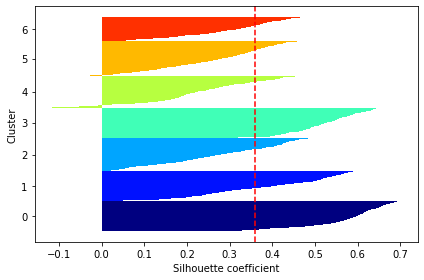

```python
plot_silhouettes(reducedDT,clusters)
```

```python
print("Completeness score: ", completeness_score(classes, clusters))
print("Homogeneity score: ", homogeneity_score(classes, clusters))
```

```
Completeness score:  0.6107955063694607
Homogeneity score:  0.609136404973329
```

There is a small difference between scores, however mean slihouettes with reduced dimensions are higher than original, and one possible reason might be data is not overfitting.

### 2. Item-Based Joke Recommendation

#### a)

Load in the joke ratings data and the joke text data into appropriate data structures. Use the "recommend" function to provide top 5 joke recommendations for at least 2 users. Use both standard item-based collaborative filtering (based on the rating prediction function "standEst") and the SVD-based version of the item-based CF (using "svdEst" as the prediction engine) to generate these recommendations for the two users and note the differences. You should show the text of the recommended jokes as well as the predicted ratings for each.

```python
df = pd.read_csv("jokes/modified_jester_data.csv", header = None)
df.head()
```

|  | 0 | 1 | 2 | 3 | 4 | 5 | 6 | 7 | 8 | 9 | ... | 90 | 91 | 92 | 93 | 94 | 95 | 96 | 97 | 98 | 99 |
| --- | --- | --- | --- | --- | --- | --- | --- | --- | --- | --- | --- | --- | --- | --- | --- | --- | --- | --- | --- | --- | --- |
| 0 | 3.18 | 19.79 | 1.34 | 2.84 | 3.48 | 2.50 | 1.15 | 15.17 | 2.02 | 6.24 | ... | 13.82 | 0.00 | 0.00 | 0.00 | 0.00 | 0.00 | 5.37 | 0.00 | 0.00 | 0.00 |
| 1 | 15.08 | 10.71 | 17.36 | 15.37 | 8.62 | 1.34 | 10.27 | 5.66 | 19.88 | 20.22 | ... | 13.82 | 6.05 | 10.71 | 18.86 | 10.81 | 8.86 | 14.06 | 11.34 | 6.68 | 12.07 |
| 2 | 0.00 | 0.00 | 0.00 | 0.00 | 20.03 | 20.27 | 20.03 | 20.27 | 0.00 | 0.00 | ... | 0.00 | 0.00 | 0.00 | 20.08 | 0.00 | 0.00 | 0.00 | 0.00 | 0.00 | 0.00 |
| 3 | 0.00 | 19.35 | 0.00 | 0.00 | 12.80 | 19.16 | 8.18 | 17.21 | 0.00 | 12.84 | ... | 0.00 | 0.00 | 0.00 | 11.53 | 0.00 | 0.00 | 0.00 | 0.00 | 0.00 | 0.00 |
| 4 | 19.50 | 15.61 | 6.83 | 5.61 | 12.36 | 12.60 | 18.04 | 15.61 | 10.56 | 16.73 | ... | 16.19 | 16.58 | 15.27 | 16.19 | 16.73 | 12.55 | 14.11 | 17.55 | 12.80 | 12.60 |

5 rows × 100 columns

```python
jokes = pd.read_csv("jokes/jokes.csv", header=None)
jokes.head()
```

|  | 0 | 1 |
| --- | --- | --- |
| 0 | 0 | A man visits the doctor. The doctor says "I ha... |
| 1 | 1 | This couple had an excellent relationship goin... |
| 2 | 2 | Q. What's 200 feet long and has 4 teeth? A. Th... |
| 3 | 3 | Q. What's the difference between a man and a t... |
| 4 | 4 | Q. What's O. J. Simpson's Internet address? A.... |

```python
def euclidSim(inA, inB):
    return 1.0/(1.0 + la.norm(inA-inB))

def pearsonSim(inA, inB):
    if len(inA) < 3:
        return 1.0
    return 0.5 + 0.5*np.corrcoef(inA,inB, rowvar=0)[0][1]

def cosineSim(inA,inB):
    num = float(inA.T*inB)
    denom = la.norm(inA) * la.norm(inB)
    return 0.5 * 0.5 *(num/denom)
```

```python
def standEst(dataMat, user, simMeas, item):
    n = np.shape(dataMat)[1]
    simTotal = 0.0; ratSimTotal = 0.0
    for j in range(n):
        userRating = dataMat[user,j]
        if userRating == 0:
            continue
        overLap = np.nonzero(np.logical_and(dataMat[:,item]>0, dataMat[:,j]>0))[0]
        if len(overLap) == 0:
            similarity = 0
        else:
            similarity = simMeas(dataMat[overLap,item], dataMat[overLap,j])
        #print('the %d and %d similarity is: %f' % (item, j, similarity))
        simTotal += similarity
        ratSimTotal += similarity * userRating
    if simTotal == 0: return 0
    else: return ratSimTotal/simTotal
```

```python
def svdEst(dataMat, user, simMeas, item):
    n = np.shape(dataMat)[1]
    simTotal = 0.0; ratSimTotal = 0.0
    data = np.mat(dataMat)
    U,Sigma,VT = la.svd(data)
    Sig4 = np.mat(np.eye(4)*Sigma[:4]) #arrange Sig4 into a diagonal matrix
    xformedItems = data.T * U[:,:4] * Sig4.I  #create transformed items
    for j in range(n):
        userRating = data[user,j]
        if userRating == 0 or j==item: continue
        similarity = simMeas(xformedItems[item,:].T, xformedItems[j,:].T)
        #print('the %d and %d similarity is: %f' % (item, j, similarity))
        simTotal += similarity
        ratSimTotal += similarity * userRating
    if simTotal == 0: return 0
    else: return ratSimTotal/simTotal
```

```python
def recommend(dataMat, user, N=3, simMeas=cosineSim, estMethod=standEst):
    unratedItems = np.nonzero(dataMat[user,:].A==0)[1] #find unrated items
    if len(unratedItems) == 0: return 'you rated everything'
    itemScores = []
    for item in unratedItems:
        estimatedScore = estMethod(dataMat, user, simMeas, item)
        itemScores.append((item, estimatedScore))
    return sorted(itemScores, key=lambda jj: jj[1], reverse=True)[:N]
```

```python
df_matrix= np.mat(df)
user1 = 22
recommend_standEst1 = recommend(df_matrix, user1, N=5, simMeas=cosineSim, estMethod=standEst)
recommend_svdEst1 = recommend(df_matrix, user1, N=5, simMeas=cosineSim, estMethod=svdEst)
```

```python
user2 = 28
recommend_standEst2 = recommend(df_matrix, user2, N=5, simMeas=cosineSim, estMethod=standEst)
recommend_svdEst2 = recommend(df_matrix, user2, N=5, simMeas=cosineSim, estMethod=svdEst)
```

```python
print("Recommended jokes for user 1 with standEst:\n")
print("Ranking\tJoke No\t  Predicted rating\n")
for i in range(len(recommend_standEst1)):
    print("{}\t  {}\t\t{}\n{}\n".format(i+1, recommend_standEst1[i][0],recommend_standEst1[i][1],
                                      jokes.iloc[recommend_standEst1[i][0]][1]))
```

```
Recommended jokes for user 1 with standEst:

Ranking	Joke No	  Predicted rating

1	  88		13.723945106997949
A radio conversation of a US naval ship with Canadian authorities ... Americans: Please divert your course 15 degrees to the North to avoid a collision.Canadians: Recommend you divert YOUR course 15 degrees to the South to avoid a collision.Americans: This is the Captain of a US Navy ship.  I say ag…

2	  97		13.71399971741189
Age and Womanhood1. Between the ages of 13 and 18 ... She is like Africa virgin and unexplored. 2. Between the ages of 19 and 35 ... She is like Asia hot and exotic. 3. Between the ages of 36 and 45 ... She is like America fully explored breathtakingly beautiful and free with her resources.4. Betwee…

3	  71		13.713536444834086
On the first day of college the Dean addressed the students pointing out some of the rules:"The female dormitory will be out-of-bounds for all male students and the male dormitory to the female students. Anybody caught breaking this rule will be fined $20 the first time." He continued "Anybody caugh…

4	  99		13.712396449308478
Q: What's the difference between greeting a Queen and greeting thePresident of the United  States?A: You only have to get on one knee to greet the queen.

5	  70		13.711675331095016
At a recent Sacramento PC Users Group meeting a company was demonstrating its latest speech-recognition software.   A representative from the company was just about ready to start the demonstration and asked everyone in the room to quiet down.Just then someone in the back of the room yelled"Format C…
```

```python
print("Recommended jokes for user 1 with svdEst:\n")
print("Ranking\tJoke No\t  Predicted rating\n")
for i in range(len(recommend_svdEst1)):
    print("{}\t  {}\t\t{}\n{}\n".format(i+1, recommend_svdEst1[i][0],recommend_svdEst1[i][1],
                                      jokes.iloc[recommend_svdEst1[i][0]][1]))
```

```
Recommended jokes for user 1 with svdEst:

Ranking	Joke No	  Predicted rating

1	  98		9.963702586498707
A bus station is where a bus stops.A train station is where a train stops.On my desk I have a work station...

2	  96		9.421607023153587
A teacher is explaining to her class how different languages use negatives differently.  She says "In all languages a positive followed by a negative or a negative followed by a positive makes a negative.  In some languages two negatives together make a positive while in others they make a negative.…

3	  97		9.194928705654108
Age and Womanhood1. Between the ages of 13 and 18 ... She is like Africa virgin and unexplored. 2. Between the ages of 19 and 35 ... She is like Asia hot and exotic. 3. Between the ages of 36 and 45 ... She is like America fully explored breathtakingly beautiful and free with her resources.4. Betwee…

4	  92		8.680631353691869
Reaching the end of a job interview the human resources person asked a young engineer fresh out of Stanford"And what starting salary were you looking for?"The engineer said "In the neighborhood of $125000 a year depending on the benefits package."The interviewer said "Well what would you say to a pa…

5	  94		8.606309668652706
Just a thought ..Before criticizing someone walk a mile in their shoes.  Then when you do criticize them you will be a mile away and have their shoes !
```

```python
print("Recommended jokes for user 2 with standEst:\n")
print("Ranking\tJoke No\t  Predicted rating\n")
for i in range(len(recommend_standEst2)):
    print("{}\t  {}\t\t{}\n{}\n".format(i+1, recommend_standEst2[i][0],recommend_standEst2[i][1],
                                      jokes.iloc[recommend_standEst2[i][0]][1]))
```

```
Recommended jokes for user 2 with standEst:

Ranking	Joke No	  Predicted rating

1	  88		13.446042696171508
A radio conversation of a US naval ship with Canadian authorities ... Americans: Please divert your course 15 degrees to the North to avoid a collision.Canadians: Recommend you divert YOUR course 15 degrees to the South to avoid a collision.Americans: This is the Captain of a US Navy ship.  I say ag…

2	  83		13.443908142499966
Q: What is the difference between Mechanical Engineers and Civil Engineers? A: Mechanical Engineers build weapons Civil Engineers build targets.

3	  96		13.443200281598052
A teacher is explaining to her class how different languages use negatives differently.  She says "In all languages a positive followed by a negative or a negative followed by a positive makes a negative.  In some languages two negatives together make a positive while in others they make a negative.…

4	  0		13.43814549128179
A man visits the doctor. The doctor says "I have bad news for you.You have cancer and Alzheimer's disease". The man replies "Well thank God I don't have cancer!"

5	  70		13.4341374282765
At a recent Sacramento PC Users Group meeting a company was demonstrating its latest speech-recognition software.   A representative from the company was just about ready to start the demonstration and asked everyone in the room to quiet down.Just then someone in the back of the room yelled"Format C…
```

```python
print("Recommended jokes for user 2 with svdEst:\n")
print("Ranking\tJoke No\t  Predicted rating\n")
for i in range(len(recommend_svdEst2)):
    print("{}\t  {}\t\t{}\n{}\n".format(i+1, recommend_svdEst2[i][0],recommend_svdEst2[i][1],
                                      jokes.iloc[recommend_svdEst2[i][0]][1]))
```

```
Recommended jokes for user 2 with svdEst:

Ranking	Joke No	  Predicted rating

1	  93		19.419519166102475
Two atoms are walking down the street when one atom says to the other "Oh my! I've lost an electron!"The second atom says"Are you sure"The first replies "I'm positive!"

2	  0		17.095672982073086
A man visits the doctor. The doctor says "I have bad news for you.You have cancer and Alzheimer's disease". The man replies "Well thank God I don't have cancer!"

3	  87		16.742958970742617
A Czechoslovakian man felt his eyesight was growing steadily worse and felt it was time to go see an optometrist. The doctor started with some simple testing and showed him a standard eye chart with letters of diminishing size: CRKBNWXSKZY. . . "Can you read this?" the doctor asked. "Read it?" the C…

4	  1		15.335639358993708
This couple had an excellent relationship going until one day he came home from work to find his girlfriend packing. He asked her why she was leaving him and she told him that she had heard awful things about him. "What could they possibly have said to make you move out?" "They told me that you were…

5	  96		14.555201643849147
A teacher is explaining to her class how different languages use negatives differently.  She says "In all languages a positive followed by a negative or a negative followed by a positive makes a negative.  In some languages two negatives together make a positive while in others they make a negative.…
```

Overall svd estimation for user 2 predicted higher scores, and standEst for user 1. Maybe predicted scores will change if we work around numbers around users.

#### b)

Complete the definition for the function "test". This function iterates over all users and for each performs evaluation (by calling the provided "cross_validate_user" function), and returns the error information necessary to compute Mean Absolute Error (MAE). Use this function to perform evaluation (with 20% test-ratio for each user) comparing MAE results using the rating prediction function "standEst" with results using the "svdEst" prediction function. [Note: See comments provided in the module for hints on accomplishing these tasks.]

```python
import sys
sys.path.insert(0,'jokes/')
```

```python
from importlib import reload

import itemBasedRec as ibr
reload(ibr)
```

```
<module 'itemBasedRec' from 'jokes\\itemBasedRec.py'>
```

```python
def test(dataMat, test_ratio, estMethod, simMeas=pearsonSim):
    t_error = 0
    t_count = 0
    for i in range(len(dataMat)):
        error, count = ibr.cross_validate_user(dataMat, i, test_ratio, eval(estMethod), simMeas)
        t_error+=error
        t_count+=count
    MAE = t_error/t_count

    return MAE
```

```python
standEst_MAE = test(df, 0.2, "standEst")
print(standEst_MAE)
```

```
3.708023520032522
```

```python
svdEst_MAE = test(df, 0.2, "svdEst")
print(svdEst_MAE)
```

```
3.631338000855049
```

```python
def print_most_similar_jokes(dataMat, jokes, queryJoke, k, metric=pearsonSim):
    jokes_transpose = dataMat.T
    sims =[]
    for i in range(len(jokes_transpose)):
        if (i==queryJoke):
            continue;
        sim = metric(jokes_transpose[queryJoke], jokes_transpose[i])
        sims.append((sim,i))
    sims.sort(reverse = True)
    print("top {} most similar jokes to {}:\n\n{}".format(k,queryJoke,jokes.iloc[queryJoke][1]))
    for i in range(k):
        joke=sims[i]
        print("\nJoke {}, similarity {:0.6f}:".format(i+1,joke[0]))
        print(jokes.iloc[joke[1]][1])
    return
```

```python
print_most_similar_jokes(df,jokes,0,5)
```

```
top 5 most similar jokes to 0:

A man visits the doctor. The doctor says "I have bad news for you.You have cancer and Alzheimer's disease". The man replies "Well thank God I don't have cancer!"

Joke 1, similarity 0.815454:
Q. What's the difference between a man and a toilet? A. A toilet doesn't follow you around after you use it.

Joke 2, similarity 0.814750:
Q: What do Monica Lewinsky and Bob Dole have in common?A: They were both upset when Bill finished first.

Joke 3, similarity 0.802881:
Q: How do you keep a computer programmer in the shower all day long?A: Give them a shampoo with a label that says"rinse lather repeat".

Joke 4, similarity 0.801244:
A woman has twins and gives them up for adoption.  One of them goes to a family in Egypt and is named "Amal."  The other goes to a  family in Spain; they name him "Juan."  Years later Juan sends a picture of himself to his mom.  Upon receiving the picture she tells her husband that she wishes she al…

Joke 5, similarity 0.798864:
What's the difference between a MacIntosh and anEtch-A-Sketch? You don't have to shake the Mac to clear the screen.
```

#### d)

[Extra Credit]: Develop your own item-based collaborative filtering recommender that uses a model-based approach (separating the training and the prediction tasks). In the training component, item-item similarities for all pairs of items are computed and stored in an appropriate data structure. Your training function should be able to use different similarity functions (passed as a parameter) including Cosine Similarity or Pearson Correlation. The prediction (or estimation) function should take as parameters a target user, an item, a value of k, and the similarities data structure and return the predicted rating on the target item for the target user. The predicted rating should be based on the weighted average of the target user's ratings on k most similar items to the target item. You should test the prediction accuracy of your estimation function (using a cross-validation similar to part b, above) and provide a plot of cross-validation accuracies across a range of values of k. Using the best value of k, demonstrate the functionality of your recommender by generating recommendations for several anecdotal users (similar to part a, above).

```python
from sklearn.model_selection import train_test_split
df_t = df.T
X_train, X_test, y_train, y_test = train_test_split(df_t, jokes, test_size=0.2, random_state = 33)
```

```python
def most_similar_items(data,metric=pearsonSim):
    sims = []
    for i in range(len(data)):
        for j in range(i, len(data)):
            if i==j:
                continue
            simMeas = metric(data[i], data[j])
            user = (simMeas, i, j)
            sims.append(user)
    sims.sort(reverse=True)
    return sims
```

```python
most_similar_items(X_train)[:5]
```

```
[(0.9366996388217678, 60, 67),
 (0.9281184407526155, 36, 67),
 (0.9211802501682792, 9, 60),
 (0.9192813981299488, 9, 67),
 (0.9107610183340304, 36, 60)]
```

```python
def prediction(user, joke, k, sims):
    simsMat = [sims[i] for i in range(len(sims)) if sims[i][1] == joke or sims[i][2]==joke][:k]
    top_jokes = []
    for i in range(len(simsMat)):
        if simsMat[i][1] != joke:
            top_jokes.append(simsMat[i][1])
        else:
            top_jokes.append(simsMat[i][2])
    rates = []
    for r in top_jokes:
        rate = df[user][r]
        if rate != 0:
            rates.append(rate)
    return np.mean(rates)
```

```python
User = 3
Joke = 4
K = 4
msi = most_similar_items(X_train)
predict_user = prediction(User, Joke, K, msi)
print("user {} for joke {} predicted: {}".format(User, Joke, predict_user))
print("actual rating for joke {} is: {}".format(Joke, df[User][Joke]))
```

```
user 3 for joke 4 predicted: 12.905
actual rating for joke 4 is: 5.61
```

```python
estimate = []
for i in range(1,100):
    estimate.append(prediction(User, Joke, i, msi))

distance = []
for j in range(len(estimate)):
    distance.append(abs(estimate[j] - df[User][Joke]))
print("estimate",estimate[:5])
print("distance",distance[:5])
```

```
estimate [10.56, 12.165, 14.719999999999999, 12.905, 12.905]
distance [4.95, 6.554999999999999, 9.11, 7.294999999999999, 7.294999999999999]
```

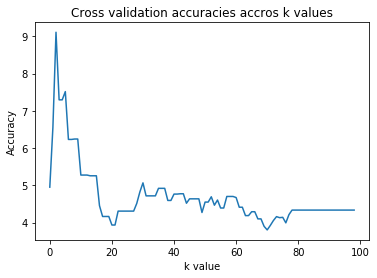

```python
plt.plot(distance)
plt.xlabel("k value")
plt.ylabel("Accuracy")
plt.title("Cross validation accuracies accros k values")
plt.show()
```

```python
User = 4
Joke = 7
b_k= distance.index(min(distance)) + 1
predict_User = prediction(User, Joke,b_k, msi)
print("user {} for joke {} predicted: {}".format(User, Joke, predict_User))
print("actual rating for joke {} is: {}".format(Joke, df[User][Joke]))
```

```
user 4 for joke 7 predicted: 10.731549295774649
actual rating for joke 7 is: 2.84
```

```python
User = 5
Joke = 15
print("user {} for joke {} predicted: {}".format(User, Joke, predict_User))
print("actual rating for joke {} is: {}".format(Joke, df[User][Joke]))
```

```
user 5 for joke 15 predicted: 10.731549295774649
actual rating for joke 15 is: 8.72
```